# Part I - (Pima Indians Diabetes Dataset)

## by Chukwunonso E. Chukwumaeze

## Introduction

> This dataset is originally from the National Institute of Diabetes and Digestive and Kidney Diseases, version was downloaded from [Kaggle](https://www.kaggle.com/datasets/uciml/pima-indians-diabetes-database)

> The datasets consists of several medical predictor variables and one target variable, Outcome. Predictor variables includes the number of pregnancies the patient has had, their BMI, insulin level, age, and so on

> Several constraints were placed on the selection of these instances from a larger database. **In particular, all patients here are females at least 21 years old of Pima Indian heritage.**

## Preliminary Wrangling

```python
# import all packages and set plots to be embedded inline
import numpy as np
import pandas as pd
import matplotlib.pyplot as plt
import seaborn as sns

%matplotlib inline
```

> In this section, my goal is to load my dataset and check for dirtiness or messiness, and fix all data quality issues if any.

```python
# Load the dataset
df = pd.read_csv('diabetes.csv')
```

```python
# confirming the size of my dataset
df.shape
```

```
(768, 9)
```

```python
df.head(5)
```

|  | Pregnancies | Glucose | BloodPressure | SkinThickness | Insulin | BMI | DiabetesPedigreeFunction | Age | Outcome |
| --- | --- | --- | --- | --- | --- | --- | --- | --- | --- |
| 0 | 6 | 148 | 72 | 35 | 0 | 33.6 | 0.627 | 50 | 1 |
| 1 | 1 | 85 | 66 | 29 | 0 | 26.6 | 0.351 | 31 | 0 |
| 2 | 8 | 183 | 64 | 0 | 0 | 23.3 | 0.672 | 32 | 1 |
| 3 | 1 | 89 | 66 | 23 | 94 | 28.1 | 0.167 | 21 | 0 |
| 4 | 0 | 137 | 40 | 35 | 168 | 43.1 | 2.288 | 33 | 1 |

> **Converting the column names to lower case for easy accessibility**

```python
# changing column name cases using the rename function
df = df.rename(columns =lambda x: x.lower())
```

> Renaming the **diabetespedigreefunction, bloodpressure and skinthickness** to better conventional standards.
> - outcome is renamed to diabetes for simplicity

```python
# renaming column using the rename function
df.rename(columns={'outcome':'diabetes','diabetespedigreefunction' : 'diabetes_pedigree_function', 'bloodpressure':'blood_pressure','skinthickness':'skin_thickness'}, inplace=True)
```

```python
# check for column names
df.columns
```

```
Index(['pregnancies', 'glucose', 'blood_pressure', 'skin_thickness', 'insulin',
       'bmi', 'diabetes_pedigree_function', 'age', 'diabetes'],
      dtype='object')
```

> Checking for missing data

```python
df.isna().sum()
```

```
pregnancies                   0
glucose                       0
blood_pressure                0
skin_thickness                0
insulin                       0
bmi                           0
diabetes_pedigree_function    0
age                           0
diabetes                      0
dtype: int64
```

> Checking for appropriate datatype for each column

```python
df.dtypes
```

```
pregnancies                     int64
glucose                         int64
blood_pressure                  int64
skin_thickness                  int64
insulin                         int64
bmi                           float64
diabetes_pedigree_function    float64
age                             int64
diabetes                        int64
dtype: object
```

> **diabetes column should be a categorical variable**

```python
from pandas.api.types import CategoricalDtype

cat = CategoricalDtype(categories=[0,1], ordered=True)
df.diabetes = df.diabetes.astype(cat)
```

```python
df.diabetes.value_counts()
```

```
0    500
1    268
Name: diabetes, dtype: int64
```

```python
df.describe()
```

|  | pregnancies | glucose | blood_pressure | skin_thickness | insulin | bmi | diabetes_pedigree_function | age |
| --- | --- | --- | --- | --- | --- | --- | --- | --- |
| count | 768.000000 | 768.000000 | 768.000000 | 768.000000 | 768.000000 | 768.000000 | 768.000000 | 768.000000 |
| mean | 3.845052 | 120.894531 | 69.105469 | 20.536458 | 79.799479 | 31.992578 | 0.471876 | 33.240885 |
| std | 3.369578 | 31.972618 | 19.355807 | 15.952218 | 115.244002 | 7.884160 | 0.331329 | 11.760232 |
| min | 0.000000 | 0.000000 | 0.000000 | 0.000000 | 0.000000 | 0.000000 | 0.078000 | 21.000000 |
| 25% | 1.000000 | 99.000000 | 62.000000 | 0.000000 | 0.000000 | 27.300000 | 0.243750 | 24.000000 |
| 50% | 3.000000 | 117.000000 | 72.000000 | 23.000000 | 30.500000 | 32.000000 | 0.372500 | 29.000000 |
| 75% | 6.000000 | 140.250000 | 80.000000 | 32.000000 | 127.250000 | 36.600000 | 0.626250 | 41.000000 |
| max | 17.000000 | 199.000000 | 122.000000 | 99.000000 | 846.000000 | 67.100000 | 2.420000 | 81.000000 |

### What is the structure of your dataset?

> The dataset contains about 768 rows with 9 columns. For my analysis I would be working on all rows and columns which includes:
> - **pregnancies** : Number of times pregnant
> - **glucose** : Plasma glucose concentration in a 2 hour oral glucose tolerance test. (mg/dL) [Read More about this test here](https://www.mayoclinic.org/tests-procedures/glucose-tolerance-test/about/pac-20394296)
> - **blood_pressure** : Diastolic blood pressure (mmHg)
> - **skin_thickness** : Triceps skin fold thickness (mm)
> - **insulin** : 2-Hour serum insulin(mu U/ml)[Read More about Insulin Tests here](https://medlineplus.gov/lab-tests/insulin-in-blood/)
> - **bmi** : Body Mass Index (weight in kg/(height in m)^2)
> - **diabetes_pedigree_function** : indicates the function which scores likelihood of diabetes based on family history.
> - **age** : everyone in this dataset is above 21 years old.
> - **diabetes** : whether individuals have diabetes or not, 0 - No, 1- Yes.

### What is/are the main feature(s) of interest in your dataset?

> I'm interested in the features that would be best predictors for diabetes in an individual

### What features in the dataset do you think will help support your investigation into your feature(s) of interest?

> All these features play a huge role as indicators for diabetes but I think these ones would have a stronger effect:
> - glucose
> - insulin
> - bmi
> - blood_pressure
> - diabetes

## Univariate Exploration

### 1. What Composition of People Have Diabetes?

```python
# Creating a function for setting the size of figures
def size(x,y):
    plt.figure(figsize=[x,y])
```

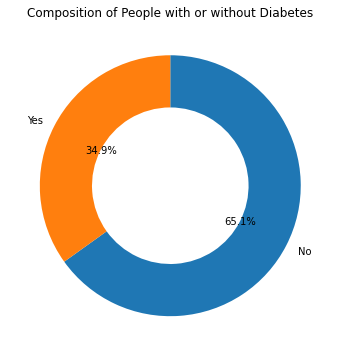

```python
outcomes = df.diabetes.value_counts()
size(8, 6)
plt.pie(outcomes, labels=['No','Yes'], startangle=90, autopct='%1.1f%%', counterclock=False, wedgeprops={'width':0.4});

plt.title("Composition of People with or without Diabetes");
```

> 34.9% of participants have diabetes while 65.1% do not have diabetes.

### 2. Distribution of BMI of the participants

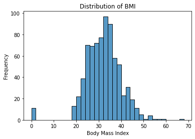

```python
bins = np.arange(0, df.bmi.max()+2, 2)
sns.histplot(data=df, x='bmi', bins=bins)

plt.xlabel('Body Mass Index')
plt.ylabel('Frequency')
plt.title('Distribution of BMI');
```

> The distribution appears fairly normal,
> - Few people have a BMI of almost 70
> - There appears to be values of zero, which is not realistic,
> - This maybe due to an error in inputting the data.
> - **How many of these zero values do we have and what can be done about it**?

```python
# checkinf for number zer0-value BMI
(df[df.bmi==0]['bmi']).count()
```

```
11
```

> Since there are only eleven of these zero values, they could be replaced with the mean bmi.

```python
# replacing the zero value BMI with the mean
# df[df.bmi==0]['bmi'] = df.bmi.mean()

df.bmi.replace(0, df.bmi.mean(), inplace=True)
```

```python
# checking for successful replacement of BMI with mean.
df.bmi.min()
```

```
18.2
```

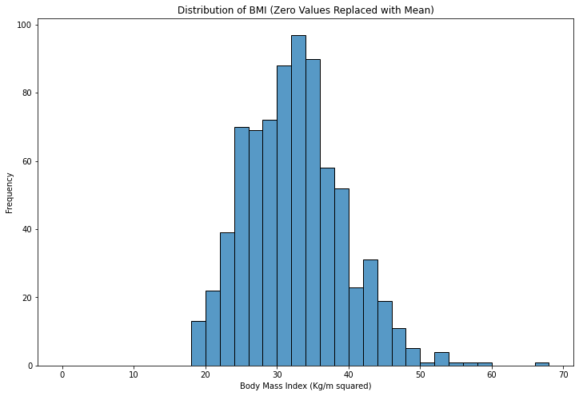

```python
# Re-plotting after replacing zero values

size(12, 8)

bins = np.arange(0, df.bmi.max()+2, 2)
sns.histplot(data=df, x='bmi', bins=bins)

plt.xlabel('Body Mass Index (Kg/m squared)')
plt.ylabel('Frequency')
plt.title('Distribution of BMI (Zero Values Replaced with Mean)');
```

> After the replacement of the zero values, the distribution is still **fairly normal**, and **unimodal** with the mode around **32-34 Kg/m2** and a little spike around **42-44 Kg/m2**
> - A few people have a BMI of about **66-68 Kg/m2**

### 3. BMI Category

#### BMI as a Diagnosing Tool for Body Fatness.

> - BMI are grouped into categories to vaguely define a person body fatness and what health risks they might be at risk for.
> - As such I would be categorising the BMI of the individuals into groups for a better idea of their body fatness.
> - A new column using the [CDC Guidelines](https://www.cdc.gov/obesity/basics/adult-defining.html) would be used to classify the BMI column into ordered categories.

```python
#  Using pd.cut to group the bmi into categories

bins = [-np.inf, 18.4, 24, 29, 34, 39, np.inf ]
labels = ['underweight','healthy-weight','overwieight','class-1-obesity','class-2-obesity','class-3-obesity']
df['bmi_category'] = pd.cut(df.bmi, bins=bins, labels=labels)
```

```python
# checking for the categorisation of bmi
df.bmi_category.dtype
```

```
CategoricalDtype(categories=['underweight', 'healthy-weight', 'overwieight',
                  'class-1-obesity', 'class-2-obesity', 'class-3-obesity'],
                 ordered=True)
```

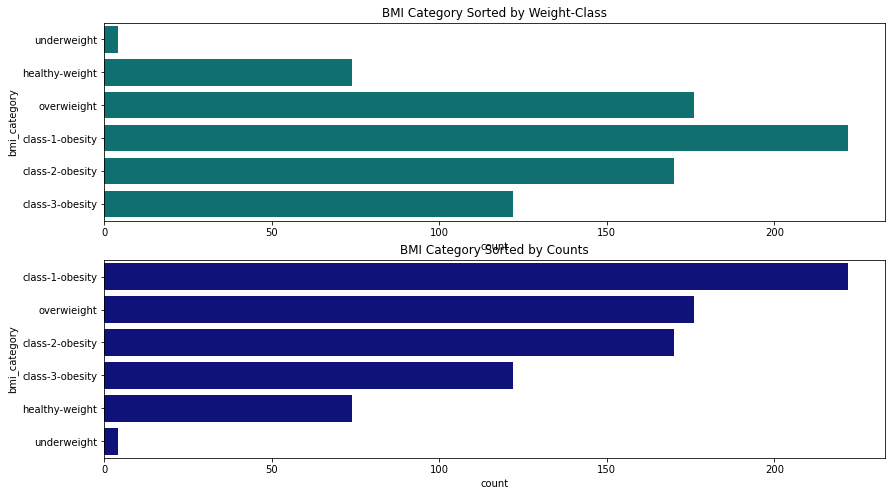

```python
size(14,8)

plt.subplot(2,1,1)
sns.countplot(data=df, y=df.bmi_category, color='teal')
plt.title('BMI Category Sorted by Weight-Class');

plt.subplot(2,1,2)
sns.countplot(data=df, y=df.bmi_category, order=df.bmi_category.value_counts().index, color='darkblue')
plt.title('BMI Category Sorted by Counts');
```

> - There are only a few underweight participants, with **most participants** belonging the **class-1-obesity** numbering over **200**, then **overweight**, and **class-2-obesity** categories both numbering over **150**

### 4. Blood Pressure.

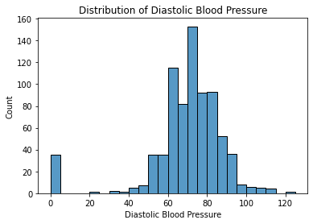

```python
bins = np.arange(0, df.blood_pressure.max()+5,5)
sns.histplot(data=df, x='blood_pressure',bins=bins);

plt.xlabel('Diastolic Blood Pressure');
plt.title('Distribution of Diastolic Blood Pressure');
```

> - There seems to appear about 35 zero values which isn't possible as nobody has a blood pressure of zero, those values would be replaced by the mean, since the data is fairly normally distributed.

```python
# replacing zero values with the mean blood pressure.
df.blood_pressure.replace(0, df.blood_pressure.mean(), inplace=True)
```

```python
# checking for replaced values
df.blood_pressure.min()
```

```
24.0
```

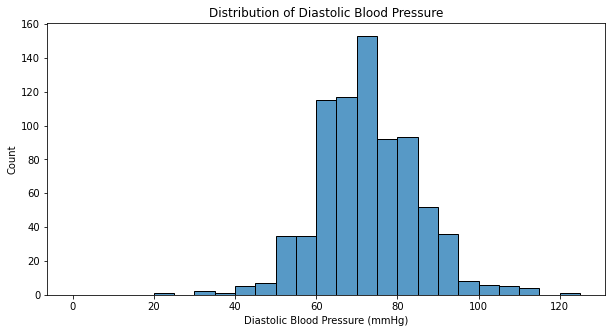

```python
# Re-plotting after removing zero values.

size(10, 5)

bins = np.arange(0, df.blood_pressure.max()+5, 5)
sns.histplot(data=df, x='blood_pressure',bins=bins);

plt.xlabel('Diastolic Blood Pressure (mmHg)');
plt.title('Distribution of Diastolic Blood Pressure');
```

> **Observation** The Diastolic Blood Pressure is roughly normally distributed, having sharp peaks at 60-65mmHg and 70-75mmHg
> - The sharp peak between the 60-65mmHg has been normalised, obviously due to the replacement of the zero values, giving us a **unimodal distribution**, with the mode around **70-75mmHg**

### 5. Glucose

```python
df.glucose.describe()
```

```
count    768.000000
mean     120.894531
std       31.972618
min        0.000000
25%       99.000000
50%      117.000000
75%      140.250000
max      199.000000
Name: glucose, dtype: float64
```

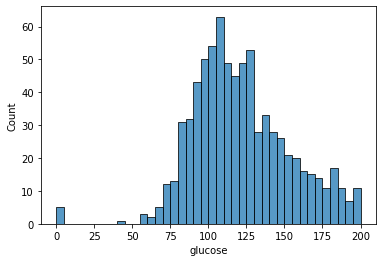

```python
bins = np.arange(0, df.glucose.max()+5, 5)
sns.histplot(data=df, x='glucose', bins=bins);
```

```python
# Replacing zero values with the mean value.
df.glucose.replace(0, df.glucose.mean(), inplace=True)

# checking for zero values
df.glucose.min()
```

```
44.0
```

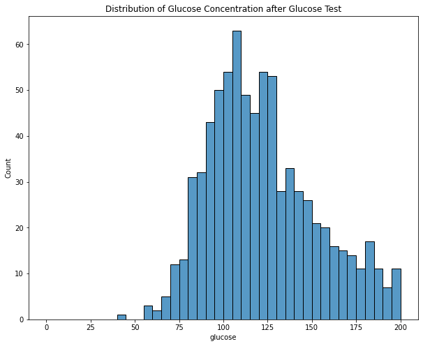

```python
# reploting the distribution.
size(10,8)

bins = np.arange(0, df.glucose.max()+5, 5)
sns.histplot(data=df, x='glucose', bins=bins);

# sns.distplot(df, x=df.glucose)

plt.title('Distribution of Glucose Concentration after Glucose Test');
```

> **OBSERVATION**
> - The distribution is very much slightly skewed to the right, it is **multimodal** with **peaks at 105-110** and another one around **120-130**

### 6. Insulin

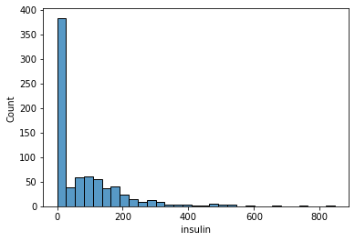

```python
sns.histplot(df, x=df.insulin);

# ticks = np.arange(0, df.insulin.max()+5, 30)
# labels = [f'{x}' for x in ticks]
# plt.xticks(ticks, labels, rotation =20);
```

> Having a lot of zero values which is not possible after a 2-hour serum-insulin test.

```python
zero_values = (df[df.insulin==0]['insulin']).count()

print(f'{zero_values}, \nPercentage composition of zero values: {((zero_values/df.shape[0])*100)}')
```

```
374,
Percentage composition of zero values: 48.69791666666667
```

> About 48% of the data is zero, the **zero values** will be **replaced** using the **ffil() *forward fill* method** Here's why:
> - Replacing with mean or median would automatically create a mode of the value, since we would be replacing 48% of the whole column.
> - Using the **ffil** method uses different values in respect to the position of the zero value and is appropriate since they're scattered all over the column, attributing a measure of randomness to the method.

```python
# Replacing the zero values with null so as to use the ffill() function
df.insulin.replace(0, np.nan, inplace=True)

df.insulin.fillna(method='ffill', inplace=True)
```

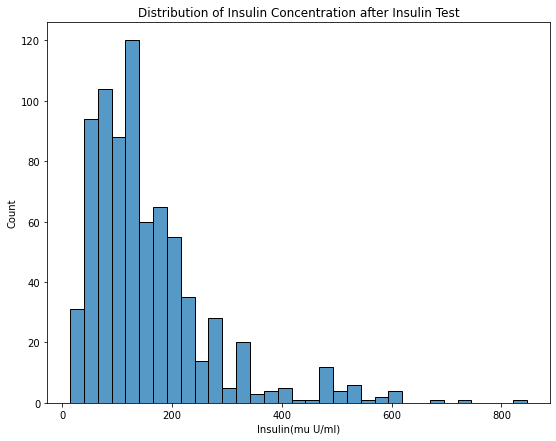

```python
#  Reploting the Histogram.
size(9,7)

sns.histplot(df, x=df.insulin);
plt.title('Distribution of Insulin Concentration after Insulin Test');

plt.xlabel("Insulin(mu U/ml)");
```

> - The distribution is highly skewed to the right, as such a logarithm transformation would be appropriate.

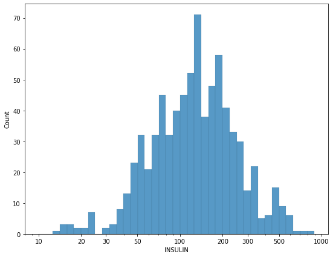

```python
size(9,7)

log_binsize = 0.05
bins = 10** np.arange(1, np.log10(df.insulin.max())+log_binsize, log_binsize)

sns.histplot(df, x=df.insulin, bins=bins);
plt.xscale('log')

ticks = [10, 20, 30, 50, 100, 200, 300, 500, 1000]
labels = [f'{x}' for x in ticks]

plt.xticks(ticks, labels);
plt.xlabel('INSULIN');
```

> **OBSERVATION**

> The Log distribution appears normal, also being multimodal, with 2 significant peaks betweem 50 and 100 and another 2 between 100 and 200, theres also another 2 betweeen 300 and 500.

### 7. Pregnancies

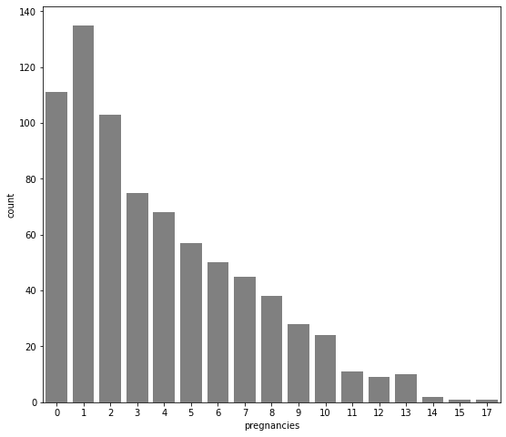

```python
size(9,8)

sns.countplot(data=df, x=df.pregnancies, color='gray');
```

> **OBSERVATION**
> - Most participants had been pregnant Once, seconded by those who have never been pregnant, the number of people decreases as the number of pregnancies increase from 2 to 13, then decreases from 14.

### 8. Diabetes Pedigree Function

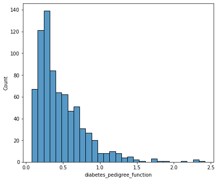

```python
size(7,6)
sns.histplot(data=df, x='diabetes_pedigree_function');
```

> Very much skewed to the right, so a log transformation would be appropriate.

```python
df.diabetes_pedigree_function.describe()
```

```
count    768.000000
mean       0.471876
std        0.331329
min        0.078000
25%        0.243750
50%        0.372500
75%        0.626250
max        2.420000
Name: diabetes_pedigree_function, dtype: float64
```

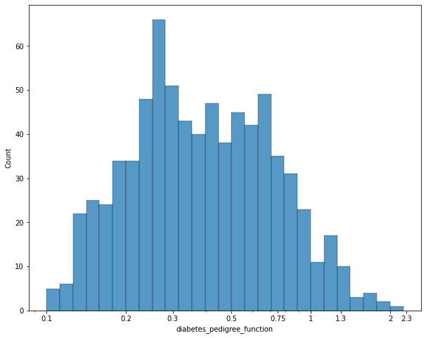

```python
size(10,8)

log_bin = 0.05
bin_size = 10 ** np.arange(-1, np.log10(df.diabetes_pedigree_function.max()+log_bin), log_bin)

sns.histplot(data=df, x='diabetes_pedigree_function', bins=bin_size)
plt.xscale('log')

ticks = [0.1,0.2, 0.3, 0.5, 0.75, 1, 1.3, 2, 2.3]
labels = [f'{x}' for x in ticks]
plt.xticks(ticks, labels);
```

> **OBSERVATION**

> The distribution of the *Diabetes Pedigree Function* is fairly bimodal, with it's major peak close to 0.3 and another close to 0.75

### 9. Skin Thickness

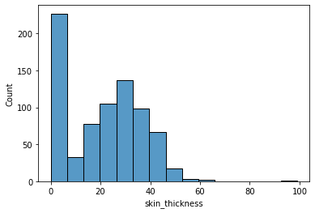

```python
sns.histplot(data=df, x=df.skin_thickness);
```

> - There are over **200 zero-values**
> - The distribution is also skewed to the right.A log distribution would appropriate.
> - They would replaced using the fillforward method, as using a single value would result in an automatic mode.

```python
# replacing zero values with Null values so as to use the ffill method.
df.skin_thickness.replace(0, np.nan, inplace=True)

# using the fill forward method to replace values
df.skin_thickness.fillna(method='ffill', inplace=True)
```

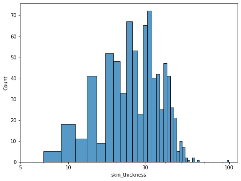

```python
size(8,6)

log_bin = 2
bins = 10** np.log10(np.arange(df.skin_thickness.min(), df.skin_thickness.max()+log_bin, log_bin))
sns.histplot(data=df, x=df.skin_thickness, bins=bins);

plt.xscale('log')

ticks = [5, 10, 30, 100]
labels = [f'{x}' for x in ticks]
plt.xticks(ticks, labels);
```

> **OBSERVATION**
> - The mode skin thickness is little above 30, with various peaks at other intervals
> - There's an outlier with an skin_thickness of 100, it's probable an error but it is neglible.

### 10. Age

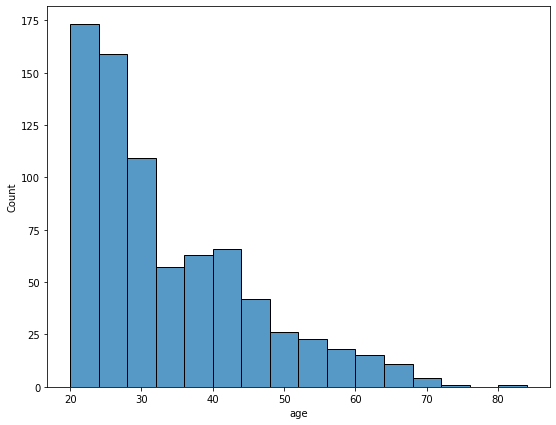

```python
size(9,7)
bins = np.arange(20, df.age.max()+4, 4)
sns.histplot(data=df, x='age', bins=bins);
```

> **OBSERVATION**
> - The skew is expected as the least age in the dataset is 21 years, as indicated -
> - The modal age is between 20-24 years, with a peak at 40-44

## Bivariate Exploration

### 1. Are people with higher BMI more susceptible to diabetes?

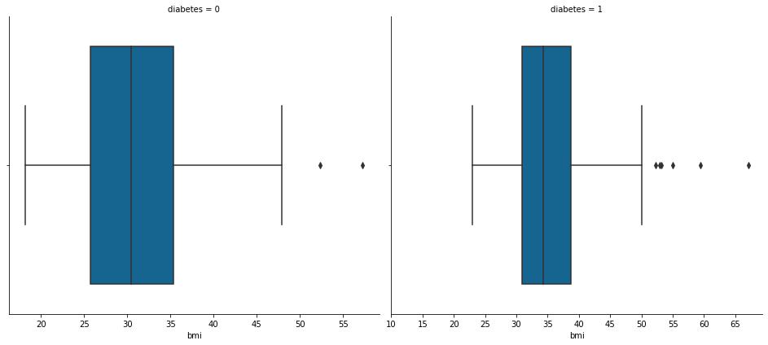

```python
plt.style.use('tableau-colorblind10')

g = sns.FacetGrid(data=df, col='diabetes', sharex=False, height=6, aspect=1.1)
g.map(sns.boxplot, 'bmi', order=[0,1]);

ticks = [x for x in range(10, 70, 5)]
labels = [f'{x}' for x in ticks]

plt.xticks(ticks, labels);
```

> **OBSERVATION**
> - Those **without diabetes** had a **median bmi of about 30** and an *IQR range of 25-35*
> - While those **with diabetes** had a **median bmi of about 35** and an *IQR range of about 31-39*

> Investigating the BMI-Diabetes relationship further by looking at the BMI Categories.

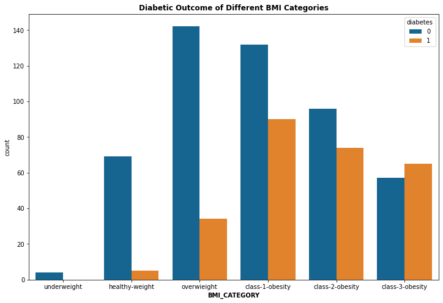

```python
size(12,8)

sns.countplot(data=df, x='bmi_category', hue='diabetes')

plt.xlabel("BMI_CATEGORY", weight='bold')
plt.title('Diabetic Outcome of Different BMI Categories', weight='bold');
```

> **OBSERVATION**
> - Just as the previous plot showed a bit of overlap in all weight categories except the underweight category, which is expected.
> - Class-1-Obesity category has the highest number of diabetic participants and also the second highest number of non-diabetic participants
> - Number of diabetic participants increases from none in the underweight category to the most in the class-1-obesity category and decreases towards the class-3-obesity

> **NOTE** It is also worthy of note that the number of each category in the dataset isn't equal.

### 2. What influence does Glucose and Insulin levels on Daibetes?

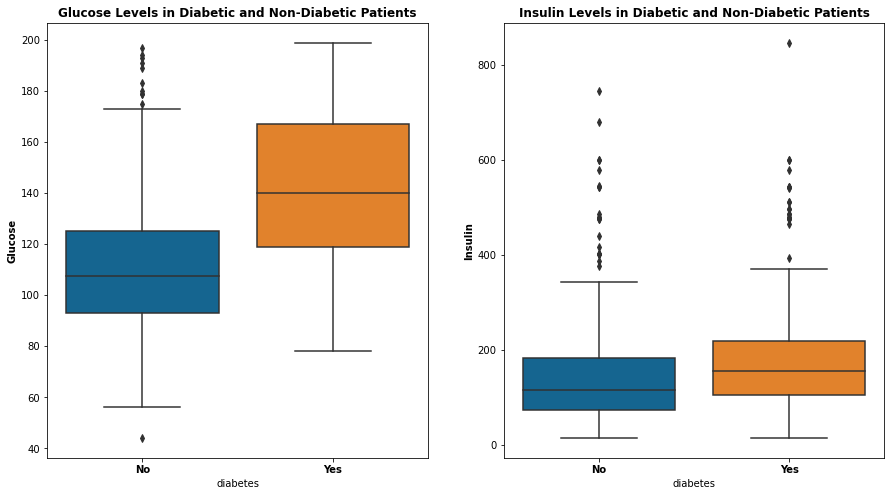

```python
size(15,8)


plt.subplot(1,2,1)
plt.title('Glucose Levels in Diabetic and Non-Diabetic Patients', weight='heavy')
sns.boxplot(data=df, x='diabetes', y='glucose')
plt.ylabel('Glucose', weight='bold')
plt.xticks([0, 1], ["No", "Yes"], weight='bold');

plt.subplot(1,2,2)
plt.title('Insulin Levels in Diabetic and Non-Diabetic Patients', weight='heavy')
sns.boxplot(data=df, x='diabetes', y='insulin');
plt.ylabel('Insulin', weight='bold')
plt.xticks([0, 1], ["No", "Yes"], weight='bold');
```

> **OBSERVATION**
> - People with diabetes have a **higher glucose level** than those without.
> - Diabetic participants had a **higher insulin level** than those without diabetes although there **seems to be a lot of overlap** between the two categories.

### 3. What is the relationship between the Blood Pressure and Diabetes Status of the participants?

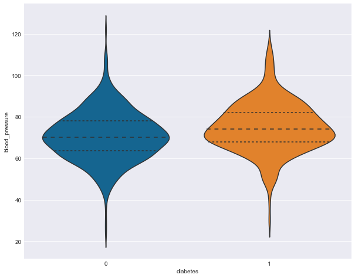

```python
plt.style.use('seaborn-darkgrid')
size(10,8)
sns.violinplot(data=df, x='diabetes', y='blood_pressure', alpha=0.6, inner='quartile');
```

> **OBSERVATION**
> - The distribution of the Diastolic Pressure of both categories appears fairly the same, but those with diabetes have a slightly higher median and IQR of Diastolic Blood Pressure than those without diabetes.

### 4. What is the relationship between the age and Diabetes Status of the participants?

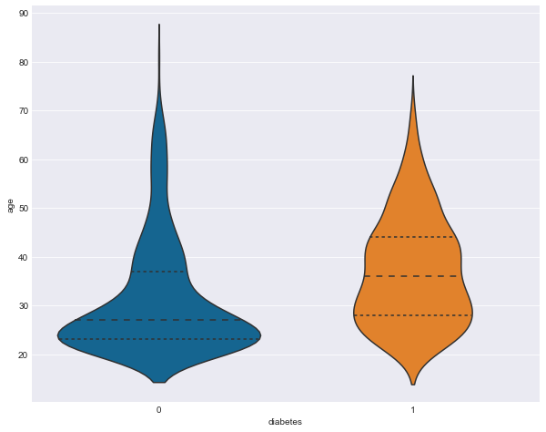

```python
size(10,8)
sns.violinplot(data=df, x='diabetes', y='age', alpha=0.6, inner='quartile');
```

```python
df.groupby('diabetes')['age'].describe()
```

| diabetes | count | mean | std | min | 25% | 50% | 75% | max |
| --- | --- | --- | --- | --- | --- | --- | --- | --- |
| 0 | 500.0 | 31.190000 | 11.667655 | 21.0 | 23.0 | 27.0 | 37.0 | 81.0 |
| 1 | 268.0 | 37.067164 | 10.968254 | 21.0 | 28.0 | 36.0 | 44.0 | 70.0 |

> **OBSERVATION**
> - Most people with diabetes were older than those without diabetes,
> - Most diabetic participants are around 30 years and 40 years as indicated by the distribution in the violinplot, with a larger population around the 30 year mark
> - The **median age of diabetic particpants around 36 years**
> - The **median age of nondiabetic participants is around 27 years**

### 5. Relationship between number of pregnancies and bmi?

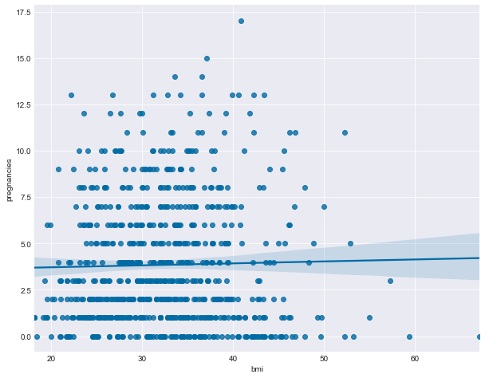

```python
size(10,8)
sns.regplot(data=df, y='pregnancies', x='bmi');
```

> **OBSERVATION**
> - Contrary to what I was expecting, number of pregnancies wasn't a contributor to the increase in BMI of a participant.

### 6. Relationship between number of pregnancies and Skin Thickness?

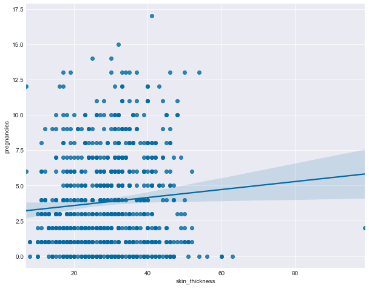

```python
size(10,8)
sns.regplot(data=df, y='pregnancies', x='skin_thickness');
```

> **OBSERVATION**
> - This further confirms that pregnancy wasn't a significant contributor to weight gain, as most people had between 0-5 pregnancies.

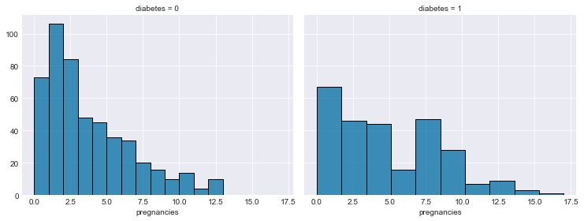

```python
g = sns.FacetGrid(data=df, col='diabetes', height=4, aspect=1.3, sharex=True)
g.map(sns.histplot,'pregnancies');
```

### 7. Relationship between number of Diabetes Pedigree Function and Diabetes Status

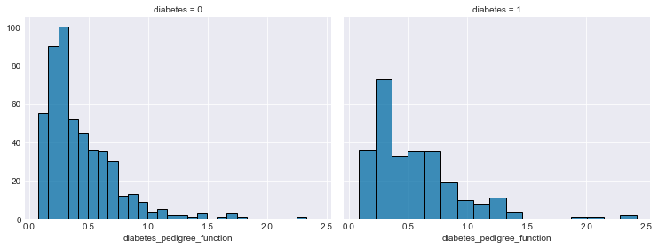

```python
g = sns.FacetGrid(data=df, col='diabetes', height=4, aspect=1.3)
g.map(sns.histplot,'diabetes_pedigree_function');
```

> **OBSERVATION**
> - The distributions of the diabetes_pedigree_function of both diabetic and nondiabetic participants were fairly the same.

### 8. Relationship between Skin Thickness and BMI

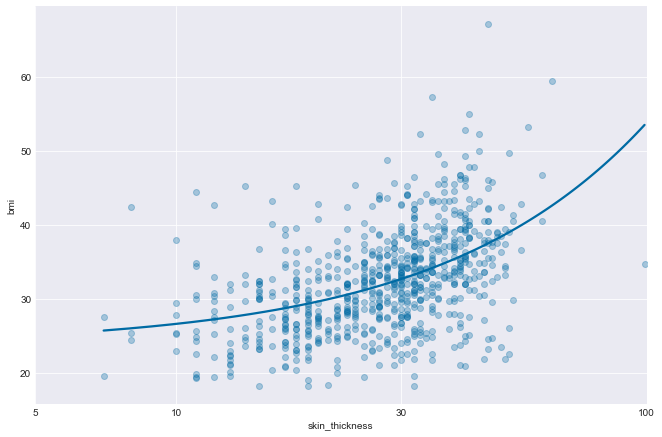

```python
sns.lmplot(data=df, x='skin_thickness', y='bmi', height=6, aspect = 1.5, scatter_kws={"alpha":0.3}, ci=None)

plt.xscale('log')
ticks = [5, 10, 30, 100]
labels = [f'{x}' for x in ticks]
plt.xticks(ticks, labels);
```

> **OBSERVATION**
> - The Logarithm of Skin thickness has a positive correlation with BMI, with concentrations between BMI of 25-40 and skin thickness of 15-40

### Talk about some of the relationships you observed in this part of the investigation. How did the feature(s) of interest vary with other features in the dataset?

> - Insulin, Glucose, BMI and Blood Pressure showed differences in the diabetes status of each participant, while the number of pregnancies didn't correlate with BMI or skin thickness.
> - There's positive correlation between BMI and skin thickness

### Did you observe any interesting relationships between the other features (not the main feature(s) of interest)?

> - The Age distribution of diabetic participants clustered around the 30 and 40 year mark, with a median age of 36.
> - Median age of non-diabetic patients is 27 years.

## Multivariate Exploration

### 1. What is the Relationship between the Ages, BMI Categories and Diabetes Status of the Participants?

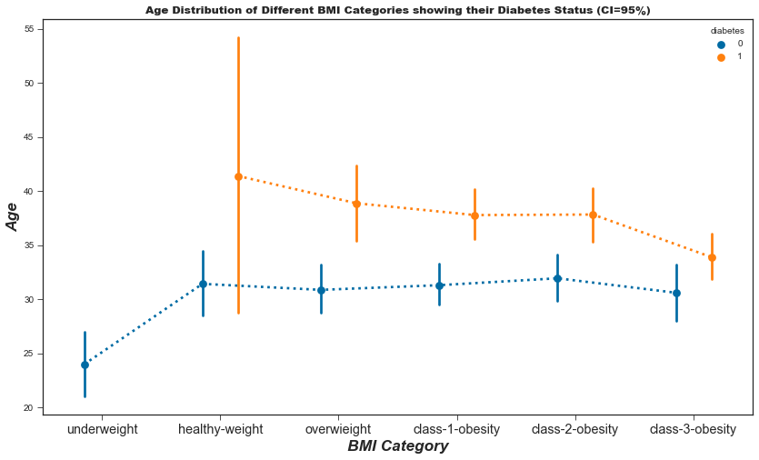

```python
plt.style.use('seaborn-ticks')
size(14,8)
sns.pointplot(data = df, x = 'bmi_category', y = 'age', hue = 'diabetes',
                  dodge = 0.3, linestyles = "dotted", ci=95)

# plt.style.available

plt.title('Age Distribution of Different BMI Categories showing their Diabetes Status (CI=95%)', weight='heavy')
plt.ylabel('Age', weight='bold', size='xx-large', fontstyle='italic')
plt.xlabel('BMI Category', weight='bold', size='xx-large', fontstyle='italic')


ticks=np.arange(0,6,1)
plt.xticks(size='x-large', weight='light');
```

> **OBSERVATION**
> - There's a significant difference in the ages of diabetic and non-diabetic participants,
> - There's no diabetic underweight participant.
> - There's a slight decrease in the age of diabetic participants as you move from healthy weight category down to the class-3-obesity category.

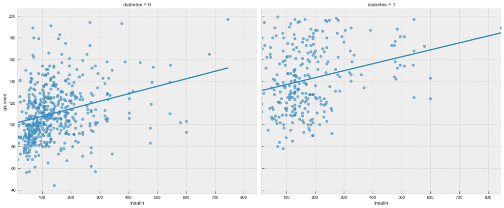

```python
plt.style.use('bmh')
g = sns.FacetGrid(data=df, col='diabetes', height=7, aspect=1.2)
g.map(sns.regplot, 'insulin', 'glucose', scatter_kws={'alpha':0.6}, ci=None)
```

> **OBSERVATION**
> - In both diabetic and non-diabetic participants, their was a positive relationship between the glucose and insulin levels
> - Glucose levels were higher in diabetic participants
> - Distribution of Insulin levels in both diabetic and non-diabetic participants were fairly the same.

### 3. How did Blood Pressure and BMI affect the Diabetes Status of the participants?

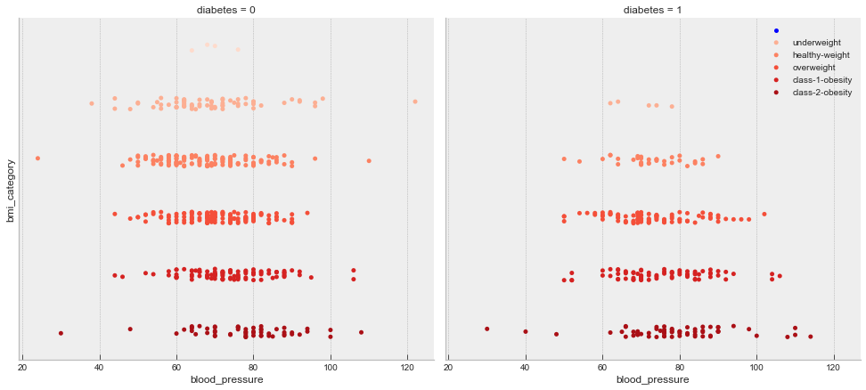

```python
sns.catplot(data=df, x='blood_pressure', y='bmi_category', col='diabetes', palette='Reds', height=6, aspect=1.2)
plt.yticks([]);
plt.legend(['','underweight', 'healthy-weight','overweight','class-1-obesity', 'class-2-obesity','class-3-obesity']);
```

> **OBSERVATION**
> - In both diabetic and non-diabetic patients, there's a slight increase in diastolic blood pressure as the BMI category increases

### 4. Correlation between Glucose, Insulin, BMI and Diabetes Status.

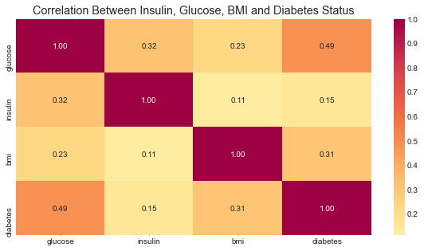

```python
size(10, 5)

# making a list of variables to be plotted on heatmap
df.diabetes = df.diabetes.astype(int)
corr = ['glucose','insulin','bmi', 'diabetes']

# correlation plo5
sns.heatmap(df[corr].corr(), annot = True,fmt = '.2f', cmap = 'Spectral_r', center=0)
plt.title('Correlation Between Insulin, Glucose, BMI and Diabetes Status');
```

### Talk about some of the relationships you observed in this part of the investigation. Were there features that strengthened each other in terms of looking at your feature(s) of interest?

> - Age of Diabetic participants were significantly higher than non-diabetic participants
> - Age of diabetic patients reduced with increase in their BMI category
> - Underweight individuals had no diabetic participant and were very much younger than other BMI categories
> - Glucose and Insulin levels had a positive correlation in both diabetic and non-diabetic participants
> - Glucose levels had the highest positive correlation with diabetes outcome, with a Pearson's Correlation Coefficient of 0.49

### Were there any interesting or surprising interactions between features?

> Blood Pressure distribution did not vary much among diabetic and non-diabetic participants.

## Conclusions

> The older the participants were, the more susceptible they became to having diabetes, with the age distribution of diabetic participants having clusters around the 30 and 40 year mark.

> Glucose levels has the highest correlation with the diabetic status of the participant.